# SQL and EDA of Election Data

Jessica Gorr

9/25/2024

# 1 Section - Objectives

The objective of this project is to create a relational database and pull various data sets together into in order to perform exploratory data analysis of Election, Unemployment, Poverty, and Education data. The goal is to learn how to use sql and data management skills to pull needed variables into one dataframe to perform necessary Exploratory Data Analysis.

## 1.1 Data Integration

### 1.1.1 Data Preparation - Initial Download and Analysis

In order to create a database all four of the datasets needed must be downloaded. Once all data is incorporated it is necessary to get a basic understanding of each dataset. The four datasets used in this project as education, which contains variables looking at education levels in various states. The second dataset is unemployment, which contains information pertaining to unemployment rates in different states and counties. The third dataset is poverty, which pertains information about poverty rates across the united states. The final dataset is contains election data, such as parties and the winning party for previous elections.

### 1.1.2 Data Preparation - Presidential Election Data

When preparing the first data set, Presidential Election Data, it must fit the following requirements: 1.only use the 2020 election data 2.only keep the data for the two major parties: Democrats and Republicans 3.aggregate the total votes and keep the winning party in the data 4.county FIPS code, State name, county name, total votes received in the winning party, and the name of the party.

```sql
SELECT
    county_fips AS fips_code,
    state,
    county_name,
    SUM(totalvotes) AS total_votes,
    CASE
        WHEN SUM(CASE WHEN party = 'DEMOCRAT' THEN candidatevotes ELSE 0 END) >
             SUM(CASE WHEN party = 'REPUBLICAN' THEN candidatevotes ELSE 0 END)
        THEN 'DEMOCRAT'
        ELSE 'REPUBLICAN'
    END AS winning_party
FROM
    election
WHERE
    year = 2020
    AND party IN ('DEMOCRAT', 'REPUBLICAN')
GROUP BY
    county_fips, state, county_name;
```

### 1.1.3 Data Preparation - Unemployment Data

When preparing the second data set, Unemployment Data, it must fit the following requirements: 1.Only keep the unemployment date in the year 2020 or the most recent year if the 2020 employment rate is unavailable 2.County FIPS code 3.Unemployment rate

I renamed ‘FIPS_Code’ to ‘fips_code’ for data consistency. Value was also renamed to unemployment_rate for clarity when it comes to merging datasets. The substring function was used on the ‘Attribute’ variable in order to extract the year 2020. This was aptly named ‘year’.

```sql
SELECT
    FIPS_Code AS fips_code,
    Value AS unemployment_rate,
    SUBSTR(Attribute, -4) AS year
FROM
    unemployment
WHERE
    year = "2020"
```

### 1.1.4 Data Preparation - Poverty Data

When preparing the third data set, Poverty Data, it must fit the following requirements: 1.Keep only 2019 poverty rate 2.County FIPS code

I renamed ‘FIPStxt’ to ‘fips_code’ for data consistancy. Value was also renamed to poverty_rate for clarity when it comes to merging datasets.

```sql
SELECT
    FIPStxt AS fips_code,
    Value as poverty_rate
FROM
    poverty
WHERE
    Attribute = "PCTPOVALL_2019";
```

### 1.1.5 Data Preparation - Education Data

When preparing the final data set, Education Data, it must fit the following requirements: 1.only keep the percentage of education levels between 2015 and 2019. a.Education levels b.less than a high school diploma c.high school diploma d.completed some college (1-3 years) e.completed four years of college 2.County FIPS code

I renamed the variables above to ‘fips_code’ and replaced all “.” with “_” in order to run a sql query.

```sql
SELECT
    fips_code,
    Percent_of_adults_with_less_than_a_high_school_diploma__2015_19,
    Percent_of_adults_with_a_high_school_diploma_only__2015_19,
    Percent_of_adults_completing_some_college_or_associate_s_degree__2015_19,
    Percent_of_adults_with_a_bachelor_s_degree_or_higher__2015_19
FROM
    education
GROUP BY
    fips_code;
```

### 1.1.6 Merge Datasets

Here I left joined all datasets together. Then, using the dplyr library, I removed all duplicates based on the fips_code and any missing observations. The final dataset is called fips_202_elections. This dataset has 3113 observations consisting of 12 variables of interest.

# 2 Exploratory Data Anaylsis

## 2.1 Univariate Analysis

The first EDA I want to do is a univariate analysis of the variable “winning_party” Below is pie chart that shows the distribution of winning parties.

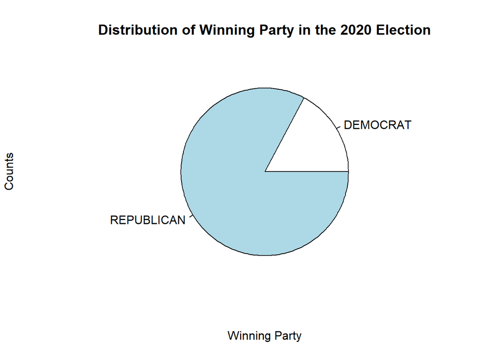

From this chart we can see that the republican party has a higher amount of winning counties than the democratic party. However, in the electoral college, it is not how many counties your party wins, but how many delegates belong to that county. In 2020 the Democratic party won the presidency, this was done by winning fewer but larger counties with more delegates.